# El paquete caret

Práctica de aplicación a problemas de clasificación

Santander Meteorology Group

# 1 1. Visualización

The `featurePlot` function is a wrapper for different lattice plots to visualize the data. For classification data sets, the iris data are used for illustration.

Scatterplot Matrix:

```r
library(caret)
```

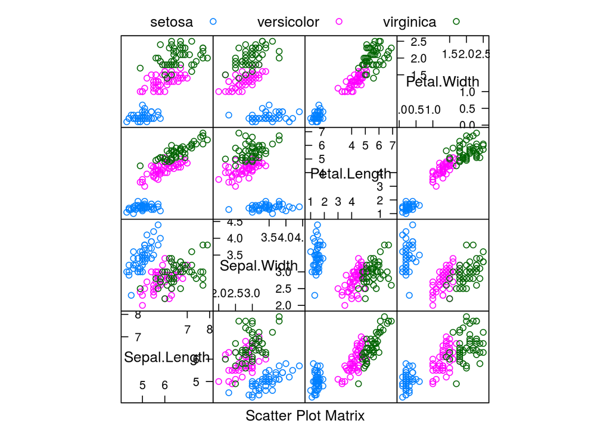

```r
featurePlot(x = iris[, 1:4],
            y = iris$Species,
            plot = "pairs",
            ## Add a key at the top
            auto.key = list(columns = 3))
```

Density Plots:

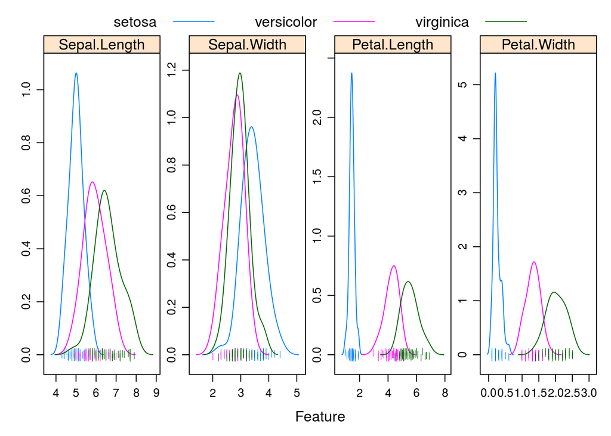

```r
featurePlot(x = iris[, 1:4],
            y = iris$Species,
            plot = "density",
            ## Pass in options to xyplot() to
            ## make it prettier
            scales = list(x = list(relation="free"),
                          y = list(relation="free")),
            adjust = 1.5,
            pch = "|",
            layout = c(4, 1),
            auto.key = list(columns = 3))
```

Box Plots:

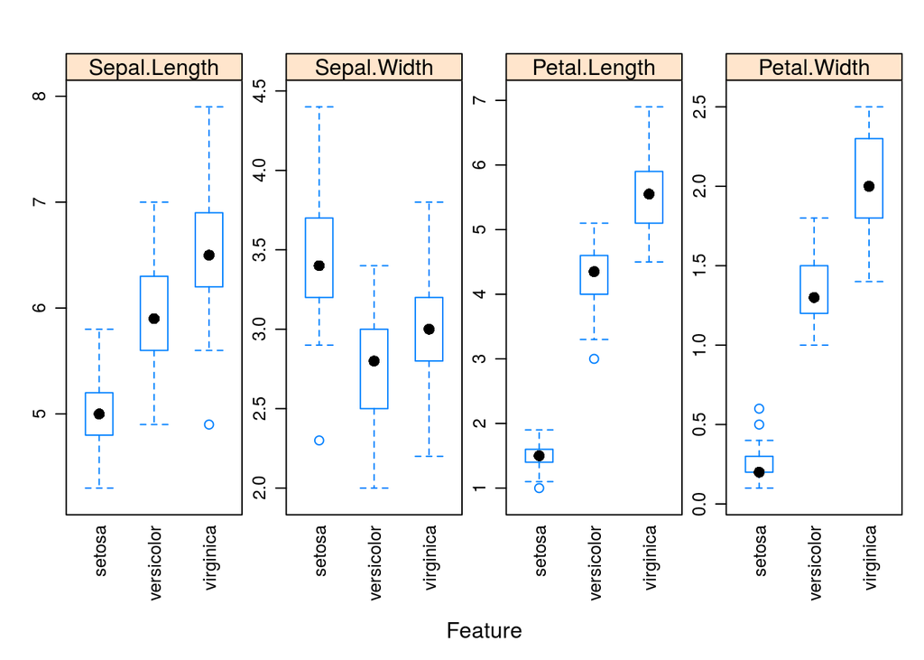

```r
featurePlot(x = iris[, 1:4],
            y = iris$Species,
            plot = "box",
            ## Pass in options to bwplot()
            scales = list(y = list(relation="free"),
                          x = list(rot = 90)),
            layout = c(4,1 ),
            auto.key = list(columns = 2))
```

# 2 2. Post-processing

## 2.1 2.1. Zero- and Near Zero-Variance Predictors

In some situations, the data generating mechanism can create predictors that only have a single unique value (i.e. a “zero-variance predictor”). For many models (excluding tree-based models), this may cause the model to crash or the fit to be unstable.

Similarly, predictors might have only a handful of unique values that occur with very low frequencies. For example, in the drug resistance data, the nR11 descriptor (number of 11-membered rings) data have a few unique numeric values that are highly unbalanced:

```r
data(mdrr)
?mdrr
```

```r
message("data dimension")
```

```
## data dimension
```

```r
dim(mdrrDescr)
```

```
## [1] 528 342
```

```r
message("summary of variable nR11")
```

```
## summary of variable nR11
```

```r
data.frame(table(mdrrDescr$nR11))
```

```
##   Var1 Freq
## 1    0  501
## 2    1    4
## 3    2   23
```

The concern here that these predictors may become zero-variance predictors when the data are split into cross-validation/bootstrap sub-samples or that a few samples may have an undue influence on the model. These “near-zero-variance” predictors may need to be identified and eliminated prior to modeling.

```r
nzv <- nearZeroVar(mdrrDescr, saveMetrics= TRUE)
nzv[nzv$nzv,][1:10,]
```

```
##        freqRatio percentUnique zeroVar  nzv
## nTB     23.00000     0.3787879   FALSE TRUE
## nBR    131.00000     0.3787879   FALSE TRUE
## nI     527.00000     0.3787879   FALSE TRUE
## nR03   527.00000     0.3787879   FALSE TRUE
## nR08   527.00000     0.3787879   FALSE TRUE
## nR11    21.78261     0.5681818   FALSE TRUE
## nR12    57.66667     0.3787879   FALSE TRUE
## D.Dr03 527.00000     0.3787879   FALSE TRUE
## D.Dr07 123.50000     5.8712121   FALSE TRUE
## D.Dr08 527.00000     0.3787879   FALSE TRUE
```

By default, `nearZeroVar` will return the positions of the variables that are flagged to be problematic:

```r
nzv <- nearZeroVar(mdrrDescr)
filteredDescr <- mdrrDescr[, -nzv]
dim(filteredDescr)
```

```
## [1] 528 297
```

## 2.2 2.2. Identifying Correlated Predictors

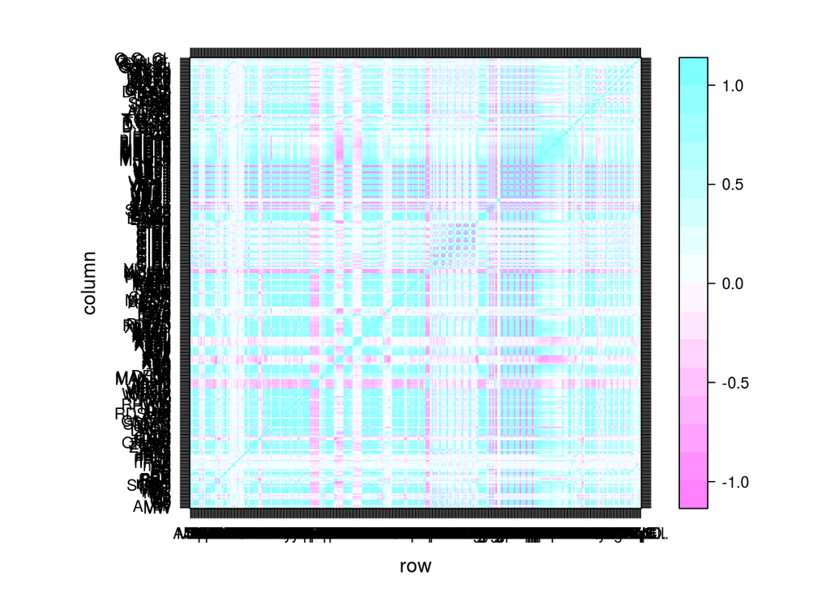

```r
descrCor <-  cor(filteredDescr)
levelplot(descrCor)
```

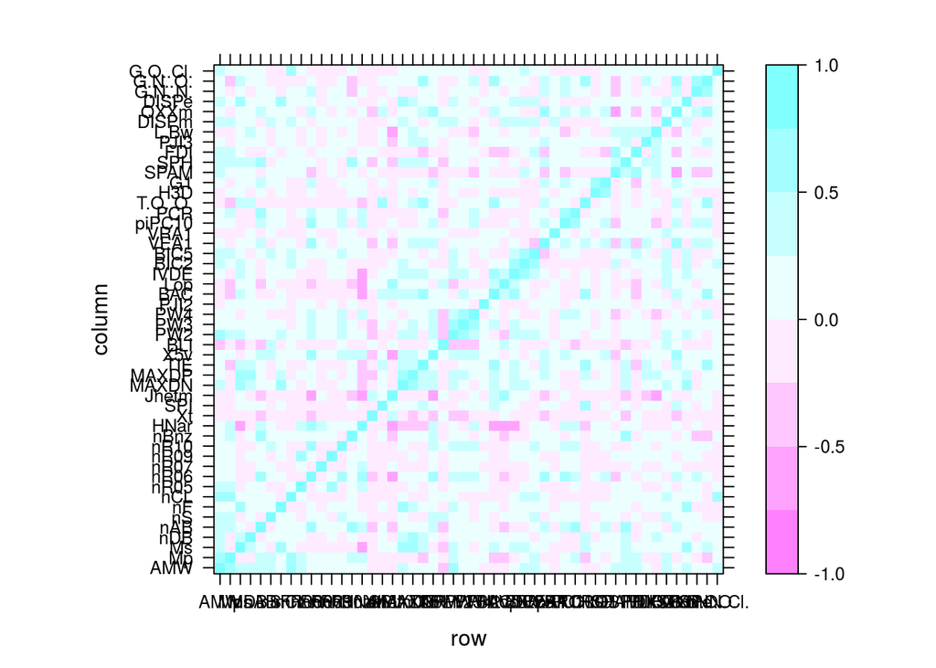

```r
highlyCorDescr <- findCorrelation(descrCor, cutoff = .75)
filteredDescr <- filteredDescr[,-highlyCorDescr]
descrCor2 <- cor(filteredDescr)
levelplot(descrCor2, at = seq(-1, 1, 0.25))
```

## 2.3 2.3. The preProcess Function

The `preProcess class` can be used for many operations on predictors, including centering and scaling. The function `preProcess` estimates the required parameters for each operation and `predict.preProcess` is used to apply them to specific data sets. In other words, the `preProcess` function estimates whatever it requires from a specific data set (e.g. the training set) and then applies these transformations to any data set without recomputing the values (e.g. the test set).

### 2.3.1 Centering and Scaling

In the example below, the half of the MDRR data are used to estimate the location and scale of the predictors.

```r
set.seed(96)
inTrain <- sample(seq(along = mdrrClass), length(mdrrClass)/2)

# Predictores
training <- filteredDescr[inTrain,]
test <- filteredDescr[-inTrain,]

# Predictando
trainMDRR <- mdrrClass[inTrain]
testMDRR <- mdrrClass[-inTrain]
```

```r
preProcValues <- preProcess(training, method = c("center", "scale"))
str(preProcValues)
```

```
## List of 21
##  $ dim              : int [1:2] 264 50
##  $ bc               : NULL
##  $ yj               : NULL
##  $ et               : NULL
##  $ invHyperbolicSine: NULL
##  $ mean             : Named num [1:50] 7.034 0.654 2.138 0.72 12.871 ...
##   ..- attr(*, "names")= chr [1:50] "AMW" "Mp" "Ms" "nDB" ...
##  $ std              : Named num [1:50] 0.7796 0.0303 0.225 0.8256 3.7516 ...
##   ..- attr(*, "names")= chr [1:50] "AMW" "Mp" "Ms" "nDB" ...
##  $ ranges           : NULL
##  $ rotation         : NULL
##  $ method           :List of 3
##   ..$ center: chr [1:50] "AMW" "Mp" "Ms" "nDB" ...
##   ..$ scale : chr [1:50] "AMW" "Mp" "Ms" "nDB" ...
##   ..$ ignore: chr(0)
##  $ thresh           : num 0.95
##  $ pcaComp          : NULL
##  $ numComp          : NULL
##  $ ica              : NULL
##  $ wildcards        :List of 2
##   ..$ PCA: chr(0)
##   ..$ ICA: chr(0)
##  $ k                : num 5
##  $ knnSummary       :function (x, ...)
##  $ bagImp           : NULL
##  $ median           : NULL
##  $ data             : NULL
##  $ rangeBounds      : num [1:2] 0 1
##  - attr(*, "class")= chr "preProcess"
```

Application:

```r
trainTransformed <- predict(preProcValues, training)
testTransformed <- predict(preProcValues, test)
```

Check outputs…

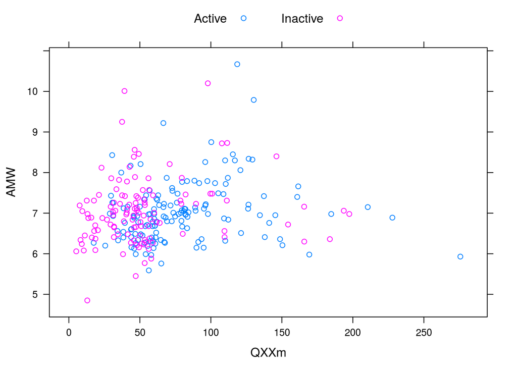

```r
xyplot(AMW ~ QXXm,
       data = training,
       groups = trainMDRR,
       auto.key = list(columns = 2))
```

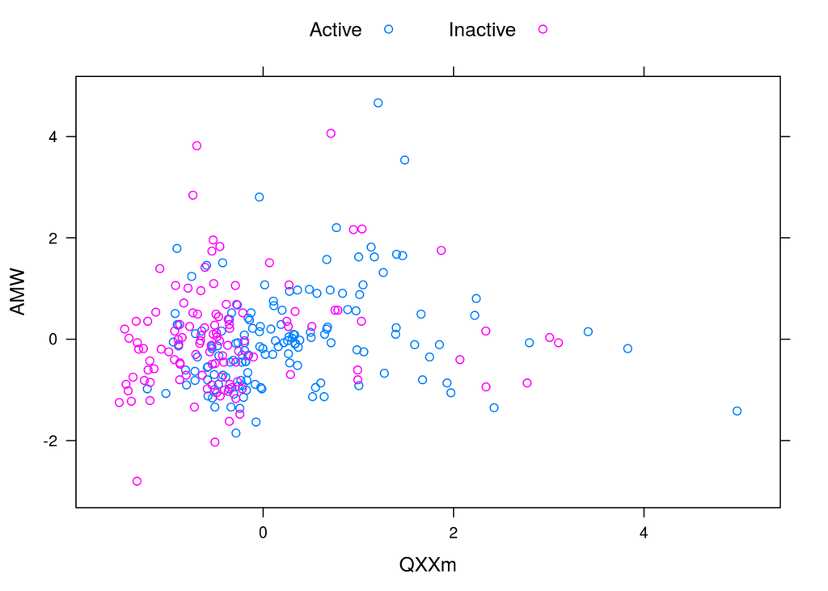

```r
xyplot(AMW ~ QXXm,
       data = trainTransformed,
       groups = trainMDRR,
       auto.key = list(columns = 2))
```

```r
mean(training$AMW)
```

```
## [1] 7.034242
```

```r
mean(trainTransformed$AMW)
```

```
## [1] 1.223838e-16
```

### 2.3.2 Transforming Predictors

In some cases, there is a need to use principal component analysis (PCA) to transform the data to a smaller sub–space where the new variable are uncorrelated with one another. The preProcess class can apply this transformation by including “pca” in the method argument. Doing this **will also force scaling of the predictors**.

```r
preProcValues <- preProcess(training, method = "pca")
preProcValues
```

```
## Created from 264 samples and 50 variables
##
## Pre-processing:
##   - centered (50)
##   - ignored (0)
##   - principal component signal extraction (50)
##   - scaled (50)
##
## PCA needed 28 components to capture 95 percent of the variance
```

```r
preProcValues <- preProcess(training, method = "pca", pcaComp = 20)
preProcValues
```

```
## Created from 264 samples and 50 variables
##
## Pre-processing:
##   - centered (50)
##   - ignored (0)
##   - principal component signal extraction (50)
##   - scaled (50)
##
## PCA used 20 components as specified
```

## 2.4 2.4 Data Splitting

### 2.4.1 Simple Splitting Based on the target variable

The function `createDataPartition` can be used to create **balanced splits of the data**. If the y argument to this function is a factor, the random sampling occurs within each class and should preserve the overall class distribution of the data.

```r
?createDataPartition
```

For example, to create a single 80/20% split of the iris data:

```r
set.seed(3456)
trainIndex <- createDataPartition(iris$Species, p = .8,
                                  list = FALSE,
                                  times = 1)
irisTrain <- iris[trainIndex,]
irisTest  <- iris[-trainIndex,]
table(irisTrain$Species)
```

```
##
##     setosa versicolor  virginica
##         40         40         40
```

```r
table(irisTest$Species)
```

```
##
##     setosa versicolor  virginica
##         10         10         10
```

```r
irisTrainFolds <- createFolds(iris$Species, k = 10)
str(irisTrainFolds)
```

```
## List of 10
##  $ Fold01: int [1:15] 27 28 38 41 42 51 58 74 85 96 ...
##  $ Fold02: int [1:15] 12 16 17 21 45 56 86 89 92 97 ...
##  $ Fold03: int [1:15] 1 8 22 23 49 52 65 71 88 100 ...
##  $ Fold04: int [1:15] 33 34 37 40 44 53 67 69 84 93 ...
##  $ Fold05: int [1:15] 6 20 24 35 46 59 66 68 95 99 ...
##  $ Fold06: int [1:15] 4 9 25 26 36 54 73 77 80 98 ...
##  $ Fold07: int [1:15] 2 15 19 30 50 57 62 64 79 87 ...
##  $ Fold08: int [1:15] 5 10 13 18 32 55 60 70 76 82 ...
##  $ Fold09: int [1:15] 7 11 39 43 47 63 75 78 81 94 ...
##  $ Fold10: int [1:15] 3 14 29 31 48 61 72 83 90 91 ...
```

```r
table(iris[irisTrainFolds[[1]],]$Species)
```

```
##
##     setosa versicolor  virginica
##          5          5          5
```

```r
table(iris[irisTrainFolds[[5]],]$Species)
```

```
##
##     setosa versicolor  virginica
##          5          5          5
```

### 2.4.2 Splitting Based on the Predictors

Also, the function `maxDissim` can be used to create sub–samples using a maximum dissimilarity approach (Willett, 1999). Suppose there is a data set **A with m samples** and **a larger data set B with n samples**. We may want to **create a sub–sample from B that is diverse when compared to A**.

For instance, lets say that we are using an **initial random sample of a data frame**. Then we can **select 20 more smples** from the data so that the new compounds are most dissimilar from the initial 5 that were specified.

```r
data(cars)
cars1 <- cars[,c("Price", "Mileage")]

## A random sample of 5 data points
startSet <- sample(1:nrow(cars1), 5)
samplePool <- cars1[-startSet,]
start <- cars1[startSet,]
newSamp <- maxDissim(start, samplePool, n = 20)
```

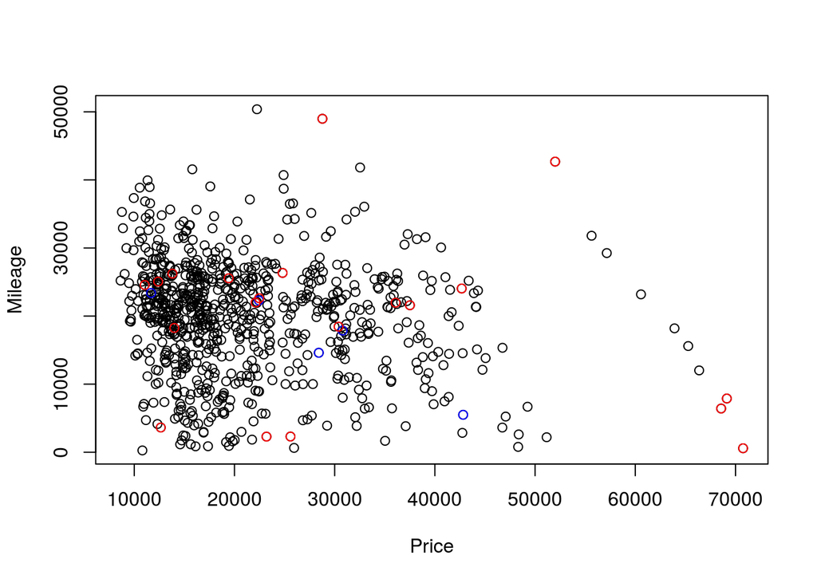

```r
plot(cars1)
points(start, col = "blue")
points(cars1[newSamp,], col = "red")
```

`createTimeSlices` for splitting time series and `groupKFold` for splitting based on different groups are other splitting functions in `caret` (see http://topepo.github.io/caret/ for more Info).

# 3 3. Model Training and Parameter Tuning

The caret package has several functions that attempt to streamline the model building and evaluation process.

The `train` function can be used to **evaluate, using resampling, the effect of model tuning parameters on performance**.

First, a specific model must be chosen. Currently, 238 are available using `caret`:

```r
models <- getModelInfo()
names(models)
```

```
##   [1] "ada"                 "AdaBag"              "AdaBoost.M1"
##   [4] "adaboost"            "amdai"               "ANFIS"
##   [7] "avNNet"              "awnb"                "awtan"
##  [10] "bag"                 "bagEarth"            "bagEarthGCV"
##  [13] "bagFDA"              "bagFDAGCV"           "bam"
##  [16] "bartMachine"         "bayesglm"            "binda"
##  [19] "blackboost"          "blasso"              "blassoAveraged"
##  [22] "bridge"              "brnn"                "BstLm"
##  [25] "bstSm"               "bstTree"             "C5.0"
##  [28] "C5.0Cost"            "C5.0Rules"           "C5.0Tree"
##  [31] "cforest"             "chaid"               "CSimca"
##  [34] "ctree"               "ctree2"              "cubist"
##  [37] "dda"                 "deepboost"           "DENFIS"
##  [40] "dnn"                 "dwdLinear"           "dwdPoly"
##  [43] "dwdRadial"           "earth"               "elm"
```

[output cut: 65 more lines]

The Sonar data are available in the `mlbench` package.

```r
install.packages("mlbench")
```

```r
library(mlbench)
data(Sonar)
str(Sonar[, 1:10])
```

```
## 'data.frame':    208 obs. of  10 variables:
##  $ V1 : num  0.02 0.0453 0.0262 0.01 0.0762 0.0286 0.0317 0.0519 0.0223 0.0164 ...
##  $ V2 : num  0.0371 0.0523 0.0582 0.0171 0.0666 0.0453 0.0956 0.0548 0.0375 0.0173 ...
##  $ V3 : num  0.0428 0.0843 0.1099 0.0623 0.0481 ...
##  $ V4 : num  0.0207 0.0689 0.1083 0.0205 0.0394 ...
##  $ V5 : num  0.0954 0.1183 0.0974 0.0205 0.059 ...
##  $ V6 : num  0.0986 0.2583 0.228 0.0368 0.0649 ...
##  $ V7 : num  0.154 0.216 0.243 0.11 0.121 ...
##  $ V8 : num  0.16 0.348 0.377 0.128 0.247 ...
##  $ V9 : num  0.3109 0.3337 0.5598 0.0598 0.3564 ...
##  $ V10: num  0.211 0.287 0.619 0.126 0.446 ...
```

The function `createDataPartition` can be used to create a stratified random sample of the data into training and test sets:

```r
library(caret)
set.seed(998)
inTraining <- createDataPartition(Sonar$Class, p = .75, list = FALSE)
training <- Sonar[ inTraining,]
testing  <- Sonar[-inTraining,]
```

## 3.1 3.1. Basic Parameter Tuning

The function `trainControl` can be used to specifiy the type of resampling:

```r
fitControl <- trainControl(## 10-fold CV
  method = "repeatedcv",
  number = 10,
  ## repeated ten times
  repeats = 10)
```

### 3.1.1 Training with function `train` (e.g. gradient boosting; the “gbm” model):

```r
install.packages("gbm")
```

Function `getModelInfo` return all the functions and metadata associated with a model

```r
getModelInfo(model = "gbm")
```

Function `modelLookup` returns useful information for parameter tuning

```r
modelLookup("gbm")
```

```
##   model         parameter                   label forReg forClass
## 1   gbm           n.trees   # Boosting Iterations   TRUE     TRUE
## 2   gbm interaction.depth          Max Tree Depth   TRUE     TRUE
## 3   gbm         shrinkage               Shrinkage   TRUE     TRUE
## 4   gbm    n.minobsinnode Min. Terminal Node Size   TRUE     TRUE
##   probModel
## 1      TRUE
## 2      TRUE
## 3      TRUE
## 4      TRUE
```

For a gradient boosting machine (GBM) model, these are tuning parameters:

- number of iterations, i.e. trees, (called n.trees in the gbm function)
- complexity of the tree, called interaction.depth
- learning rate: how quickly the algorithm adapts, called shrinkage
- the minimum number of training set samples in a node to commence splitting (n.minobsinnode)

```r
set.seed(825)
gbmFit1 <- train(Class ~ ., data = training,
                 method = "gbm",
                 trControl = fitControl,
                 ## This last option is actually one
                 ## for gbm() that passes through
                 verbose = FALSE)
gbmFit1
```

```
## Stochastic Gradient Boosting
##
## 157 samples
##  60 predictors
##   2 classes: 'M', 'R'
##
## No pre-processing
## Resampling: Cross-Validated (10 fold, repeated 10 times)
## Summary of sample sizes: 141, 141, 142, 141, 141, 142, ...
## Resampling results across tuning parameters:
##
##   interaction.depth  n.trees  Accuracy   Kappa
##   1                   50      0.7876495  0.5712306
##   1                  100      0.7957794  0.5867732
##   1                  150      0.8140441  0.6235694
##   2                   50      0.8073676  0.6101031
##   2                  100      0.8158211  0.6263183
##   2                  150      0.8244608  0.6441406
##   3                   50      0.8167843  0.6294107
##   3                  100      0.8238211  0.6432910
##   3                  150      0.8284510  0.6522968
##
## Tuning parameter 'shrinkage' was held constant at a value of 0.1
##
## Tuning parameter 'n.minobsinnode' was held constant at a value of 10
## Accuracy was used to select the optimal model using the largest value.
## The final values used for the model were n.trees = 150,
##  interaction.depth = 3, shrinkage = 0.1 and n.minobsinnode = 10.
```

The column labeled “Accuracy” is the overall agreement rate averaged over cross-validation iterations.

## 3.2 3.2. Customizing the Tuning Process

**The tuning parameter grid can be specified by the user**. The argument `tuneGrid` can take a **data frame with columns for each tuning parameter**. The column names should be the same as the fitting function’s arguments.

For instance, we can fix the learning rate and evaluate more than three values of n.trees:

```r
gbmGrid <-  expand.grid(interaction.depth = c(1, 5, 9),
                        n.trees = (1:30)*50,
                        shrinkage = 0.1,
                        n.minobsinnode = 20)
gbmGrid
```

```
##    interaction.depth n.trees shrinkage n.minobsinnode
## 1                  1      50       0.1             20
## 2                  5      50       0.1             20
## 3                  9      50       0.1             20
## 4                  1     100       0.1             20
## 5                  5     100       0.1             20
## 6                  9     100       0.1             20
## 7                  1     150       0.1             20
## 8                  5     150       0.1             20
## 9                  9     150       0.1             20
## 10                 1     200       0.1             20
## 11                 5     200       0.1             20
## 12                 9     200       0.1             20
## 13                 1     250       0.1             20
## 14                 5     250       0.1             20
```

[output cut: 76 more lines]

This grid is passed to function `train` by setting argument `tuneGrid`

```r
set.seed(825)
gbmFit2 <- train(Class ~ ., data = training,
                 method = "gbm",
                 trControl = fitControl,
                 verbose = FALSE,
                 ## Now specify the exact models
                 ## to evaluate:
                 tuneGrid = gbmGrid)
gbmFit2
```

```
## Stochastic Gradient Boosting
##
## 157 samples
##  60 predictors
##   2 classes: 'M', 'R'
##
## No pre-processing
## Resampling: Cross-Validated (10 fold, repeated 10 times)
## Summary of sample sizes: 141, 141, 142, 141, 141, 142, ...
## Resampling results across tuning parameters:
##
##   interaction.depth  n.trees  Accuracy   Kappa
##   1                    50     0.7715196  0.5383303
##   1                   100     0.7962255  0.5884175
##   1                   150     0.8134387  0.6230354
```

[output cut: 94 more lines]

Another option is to use a **random sample of possible tuning parameter combinations** by setting argument search in `trainControl`.

### 3.2.1 Práctica 1

Vuelve a repetir la calibración con el método “gbm” utilizando un máximo de 6 combinaciones de parámetros aleatorios (utiliza las páginas de ayuda de `trainControl` y `train`)

```r
fitControlrandom <- trainControl(## 10-fold CV
  method = "repeatedcv",
  number = 10,
  ## repeated ten times
  repeats = 10,
  search = "random")

set.seed(825)
gbmFitrandom <- train(Class ~ ., data = training,
                 method = "gbm",
                 trControl = fitControlrandom,
                 verbose = FALSE,
                 tuneLength = 6)
gbmFitrandom
```

```
## Stochastic Gradient Boosting
##
## 157 samples
##  60 predictors
##   2 classes: 'M', 'R'
##
## No pre-processing
## Resampling: Cross-Validated (10 fold, repeated 10 times)
## Summary of sample sizes: 141, 141, 142, 141, 141, 142, ...
## Resampling results across tuning parameters:
##
##   shrinkage   interaction.depth  n.minobsinnode  n.trees  Accuracy
##   0.07189046  6                  20              1415     0.8348088
##   0.14217520  6                  14              4054     0.7748897
##   0.17530318  6                  16              2902     0.7986078
##   0.29358551  5                  11               963     0.8141985
##   0.41732467  2                  25              3610     0.7822696
##   0.51754427  3                  19              1191     0.8035956
##   Kappa
##   0.6656629
##   0.5606690
##   0.6037088
##   0.6338043
##   0.5698479
##   0.6123259
##
## Accuracy was used to select the optimal model using the largest value.
## The final values used for the model were n.trees = 1415,
##  interaction.depth = 6, shrinkage = 0.07189046 and n.minobsinnode = 20.
```

### 3.2.2 Plotting the Resampling Profile

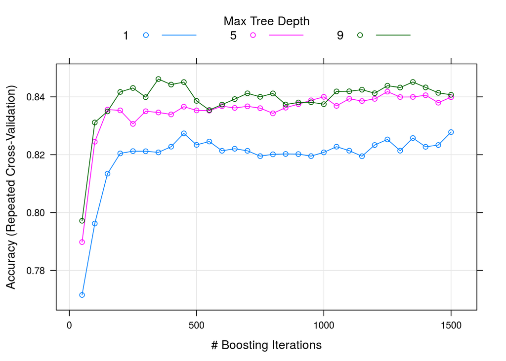

```r
# trellis.par.set(caretTheme())
plot(gbmFit2)
```

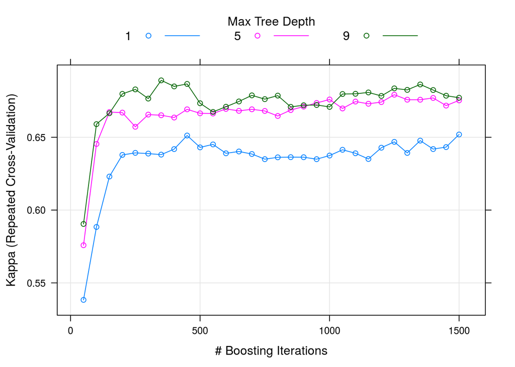

```r
plot(gbmFit2, metric = "Kappa")
```

**The user can change the metric used to determine the best settings. By default, RMSE, R2, and the mean absolute error (MAE) are computed for regression while accuracy and Kappa are computed for classification**. For example, in problems where there are a low percentage of samples in one class, using `metric = "Kappa"` can improve quality of the final model.

**Custom functions can be used to calculate performance scores that are averaged over the resamples**. For instance the `twoClassSummary` built-in function, will compute the **sensitivity, specificity and area under the ROC curve**:

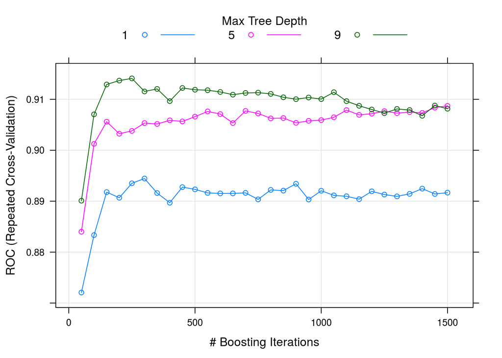

```r
fitControl <- trainControl(method = "repeatedcv",
                           number = 10,
                           repeats = 10,
                           ## Estimate class probabilities
                           classProbs = TRUE,
                           ## Evaluate performance using
                           ## the following function
                           summaryFunction = twoClassSummary)

set.seed(825)
gbmFit3 <- train(Class ~ ., data = training,
                 method = "gbm",
                 trControl = fitControl,
                 verbose = FALSE,
                 tuneGrid = gbmGrid,
                 ## Specify which metric to optimize
                 metric = "ROC")
plot(gbmFit3)
```

## 3.3 3.3. Choosing the Final Model

**The “results” slot of the object returned by train contains the different parameter combinations and the corresponding metric.**

```r
head(gbmFit3$results)
```

```
##    shrinkage interaction.depth n.minobsinnode n.trees       ROC      Sens
## 1        0.1                 1             20      50 0.8720635 0.8279167
## 31       0.1                 5             20      50 0.8840079 0.8297222
## 61       0.1                 9             20      50 0.8900967 0.8418056
## 2        0.1                 1             20     100 0.8833358 0.8454167
## 32       0.1                 5             20     100 0.9012550 0.8677778
## 62       0.1                 9             20     100 0.9070486 0.8686111
##         Spec      ROCSD    SensSD    SpecSD
## 1  0.7089286 0.09276585 0.1349887 0.1536654
## 31 0.7457143 0.08806100 0.1250486 0.1531535
## 61 0.7476786 0.08544334 0.1214965 0.1503846
## 2  0.7417857 0.09445175 0.1321846 0.1533069
## 32 0.7758929 0.08620067 0.1277290 0.1558481
## 62 0.7889286 0.08498991 0.1252790 0.1341690
```

### 3.3.1 Práctica 2:

Elegid el mejor modelo de `gbmFit3` y utilizando las funciones `best` y `tolerance`, utiliza diferentes valores para el argumento tol (e.g. 2, 10, ..). ¿Qué diferencias se ven en los parámetros y la métrica? ¿Para qué sirve el argumento tol?

```r
?best
```

```r
whichBest <- best(gbmFit3$results, metric = "ROC", maximize = TRUE)
whichTwoPct <- tolerance(gbmFit3$results, metric = "ROC",
                         tol = 2, maximize = TRUE)
whichTenPct <- tolerance(gbmFit3$results, metric = "ROC",
                         tol = 10, maximize = TRUE)
gbmFit3$results[whichBest, ]
```

```
##    shrinkage interaction.depth n.minobsinnode n.trees       ROC      Sens
## 65       0.1                 9             20     250 0.9141096 0.8830556
##         Spec      ROCSD    SensSD    SpecSD
## 65 0.7978571 0.08200484 0.1238833 0.1412217
```

```r
gbmFit3$results[whichTwoPct, ]
```

```
##    shrinkage interaction.depth n.minobsinnode n.trees      ROC      Sens
## 32       0.1                 5             20     100 0.901255 0.8677778
##         Spec      ROCSD   SensSD    SpecSD
## 32 0.7758929 0.08620067 0.127729 0.1558481
```

```r
gbmFit3$results[whichTenPct, ]
```

```
##   shrinkage interaction.depth n.minobsinnode n.trees       ROC      Sens
## 1       0.1                 1             20      50 0.8720635 0.8279167
##        Spec      ROCSD    SensSD    SpecSD
## 1 0.7089286 0.09276585 0.1349887 0.1536654
```

# 4 4 Training and Prediction

In cases where the model tuning values are known, `train` can be used to **fit the model to the entire training set without any resampling or parameter tuning** by using the `method = "none"` option in `trainControl`. For example:

```r
fitControl <- trainControl(method = "none", classProbs = TRUE)

set.seed(825)
gbmFit4 <- train(Class ~ ., data = training,
                 method = "gbm",
                 trControl = fitControl,
                 verbose = FALSE,
                 ## Only a single model can be passed to the
                 ## function when no resampling is used:
                 tuneGrid = data.frame(interaction.depth = 5,
                                       n.trees = 100,
                                       shrinkage = .1,
                                       n.minobsinnode = 20),
                 metric = "ROC")
gbmFit4
```

```
## Stochastic Gradient Boosting
##
## 157 samples
##  60 predictors
##   2 classes: 'M', 'R'
##
## No pre-processing
## Resampling: None
```

The output model will be used for prediction (function `predict`):

```r
out4 <- predict(gbmFit4, newdata = testing)
out4
```

```
##  [1] R R R R M M R R R R R R R R R R R R R R M M M R M M M R M M M M M M M
## [36] M M M M M M M M R M M M M M M M
## Levels: M R
```

```r
out4prob <- predict(gbmFit4, newdata = testing, type = "prob")
head(out4prob)
```

```
##             M          R
## 1 0.129181487 0.87081851
## 2 0.039369722 0.96063028
## 3 0.002722481 0.99727752
## 4 0.076762607 0.92323739
## 5 0.959529367 0.04047063
## 6 0.622319826 0.37768017
```